# BDA 640 Final Project

Sajjiynie Suraweera and Abhishek Gundala

2024-02-29

#Loading the data

```r
OUData <- read.csv("OUData.csv")

head(OUData)
```

```
##   ObservationRecordKey Age Gender PrimaryInsuranceCategory
## 1             905459x1  54   Male           MEDICAID STATE
## 2             443621z2  89 Female                 MEDICARE
## 3             131565z1  83 Female                 MEDICARE
## 4             438080x1  89 Female                 MEDICARE
## 5             763005z1  81 Female           MEDICARE OTHER
## 6             244227z1  54 Female           MEDICARE OTHER
##   InitPatientClassAndFirstPostOUClass Flipped OU_LOS_hrs DRG01
## 1              OBSERVATION->INPATIENT       1       37.3   428
## 2            OBSERVATION->OBSERVATION       0       89.7   599
## 3              OBSERVATION->INPATIENT       1       96.3   786
## 4            OBSERVATION->OBSERVATION       0       13.3   780
## 5            OBSERVATION->OBSERVATION       0       25.4   428
## 6            OBSERVATION->OBSERVATION       0       18.3   786
##   BloodPressureUpper BloodPressureLower BloodPressureDiff Pulse PulseOximetry
## 1                153                111                26    73           100
## 2                123                 64                68    86            94
## 3                105                 55                29    81            94
## 4                162                 73                83    76            97
## 5                102                 60                49    67            99
## 6                105                 56                63    80            99
##   Respirations Temperature
## 1           18        98.2
## 2           18        95.9
## 3           18        97.3
## 4           24        98.1
## 5           10        98.6
## 6           14        99.1
```

```r
str(OUData)
```

```
## 'data.frame':    1111 obs. of  15 variables:
##  $ ObservationRecordKey               : chr  "905459x1" "443621z2" "131565z1" "438080x1" ...
##  $ Age                                : int  54 89 83 89 81 54 83 50 52 85 ...
##  $ Gender                             : chr  "Male" "Female" "Female" "Female" ...
##  $ PrimaryInsuranceCategory           : chr  "MEDICAID STATE" "MEDICARE" "MEDICARE" "MEDICARE" ...
##  $ InitPatientClassAndFirstPostOUClass: chr  "OBSERVATION->INPATIENT" "OBSERVATION->OBSERVATION" "OBSERVATION->INPATIENT" "OBSERVATION->OBSERVATION" ...
##  $ Flipped                            : int  1 0 1 0 0 0 1 1 0 1 ...
##  $ OU_LOS_hrs                         : num  37.3 89.7 96.3 13.3 25.4 ...
##  $ DRG01                              : int  428 599 786 780 428 786 558 780 786 780 ...
##  $ BloodPressureUpper                 : chr  "153" "123" "105" "162" ...
##  $ BloodPressureLower                 : int  111 64 55 73 60 56 61 48 85 60 ...
##  $ BloodPressureDiff                  : chr  "26" "68" "29" "83" ...
##  $ Pulse                              : chr  "73" "86" "81" "76" ...
##  $ PulseOximetry                      : chr  "100" "94" "94" "97" ...
##  $ Respirations                       : chr  "18" "18" "18" "24" ...
##  $ Temperature                        : chr  "98.2" "95.9" "97.3" "98.1" ...
```

```r
summary(OUData)
```

```
##  ObservationRecordKey      Age           Gender
##  Length:1111          Min.   :19.00   Length:1111
##  Class :character     1st Qu.:57.00   Class :character
##  Mode  :character     Median :73.00   Mode  :character
##                       Mean   :69.03
##                       3rd Qu.:86.00
##                       Max.   :89.00
##  PrimaryInsuranceCategory InitPatientClassAndFirstPostOUClass    Flipped
##  Length:1111              Length:1111                         Min.   :0.0000
##  Class :character         Class :character                    1st Qu.:0.0000
##  Mode  :character         Mode  :character                    Median :0.0000
##                                                               Mean   :0.4608
##                                                               3rd Qu.:1.0000
##                                                               Max.   :1.0000
##    OU_LOS_hrs         DRG01       BloodPressureUpper BloodPressureLower
##  Min.   :  1.20   Min.   :276.0   Length:1111        Min.   :  0.00
##  1st Qu.: 24.40   1st Qu.:577.0   Class :character   1st Qu.: 65.00
##  Median : 45.80   Median :780.0   Mode  :character   Median : 74.00
##  Mean   : 62.25   Mean   :664.9                      Mean   : 75.27
##  3rd Qu.: 84.40   3rd Qu.:786.0                      3rd Qu.: 85.00
##  Max.   :405.50   Max.   :789.0                      Max.   :146.00
##  BloodPressureDiff     Pulse           PulseOximetry      Respirations
##  Length:1111        Length:1111        Length:1111        Length:1111
##  Class :character   Class :character   Class :character   Class :character
##  Mode  :character   Mode  :character   Mode  :character   Mode  :character
##
##
##
##  Temperature
##  Length:1111
##  Class :character
##  Mode  :character
##
##
##
```

#Necessary Variable transformations & Missing values

```r
factor_columns <- c("Gender", "PrimaryInsuranceCategory", "InitPatientClassAndFirstPostOUClass", "DRG01")
OUData[factor_columns] <- lapply(OUData[factor_columns], as.factor)


numeric_columns <- c("Age", "Flipped", "OU_LOS_hrs", "BloodPressureUpper", "BloodPressureLower", "BloodPressureDiff", "Pulse", "PulseOximetry", "Respirations", "Temperature")
OUData[numeric_columns] <- lapply(OUData[numeric_columns], function(x) as.numeric(as.character(x)))
OUData <- na.omit(OUData)

OUData <- OUData[OUData$BloodPressureLower != 0, ]

head(OUData)
```

```
##   ObservationRecordKey Age Gender PrimaryInsuranceCategory
## 1             905459x1  54   Male           MEDICAID STATE
## 2             443621z2  89 Female                 MEDICARE
## 3             131565z1  83 Female                 MEDICARE
## 4             438080x1  89 Female                 MEDICARE
## 5             763005z1  81 Female           MEDICARE OTHER
## 6             244227z1  54 Female           MEDICARE OTHER
##   InitPatientClassAndFirstPostOUClass Flipped OU_LOS_hrs DRG01
## 1              OBSERVATION->INPATIENT       1       37.3   428
## 2            OBSERVATION->OBSERVATION       0       89.7   599
## 3              OBSERVATION->INPATIENT       1       96.3   786
## 4            OBSERVATION->OBSERVATION       0       13.3   780
## 5            OBSERVATION->OBSERVATION       0       25.4   428
## 6            OBSERVATION->OBSERVATION       0       18.3   786
##   BloodPressureUpper BloodPressureLower BloodPressureDiff Pulse PulseOximetry
## 1                153                111                26    73           100
## 2                123                 64                68    86            94
## 3                105                 55                29    81            94
## 4                162                 73                83    76            97
## 5                102                 60                49    67            99
## 6                105                 56                63    80            99
##   Respirations Temperature
## 1           18        98.2
## 2           18        95.9
## 3           18        97.3
## 4           24        98.1
## 5           10        98.6
## 6           14        99.1
```

```r
missing_values <- sapply(OUData, function(x) sum(is.na(x)))
print(missing_values)
```

```
##                ObservationRecordKey                                 Age
##                                   0                                   0
##                              Gender            PrimaryInsuranceCategory
##                                   0                                   0
## InitPatientClassAndFirstPostOUClass                             Flipped
##                                   0                                   0
##                          OU_LOS_hrs                               DRG01
##                                   0                                   0
##                  BloodPressureUpper                  BloodPressureLower
##                                   0                                   0
##                   BloodPressureDiff                               Pulse
##                                   0                                   0
##                       PulseOximetry                        Respirations
##                                   0                                   0
##                         Temperature
##                                   0
```

#Variable Significance, Data Partition and Decision Tree

```r
set.seed(123)

target <- "Flipped"

# Remove the "ObservationRecordKey" and "InitPatientClassAndFirstPostOUClass" columns
OUData <- OUData[, !(names(OUData) %in% c("ObservationRecordKey", "InitPatientClassAndFirstPostOUClass"))]

# Data partition
inTrain <- createDataPartition(y = OUData[[target]], p = 0.75, list = FALSE)

# Split data into training and testing sets
trainData <- OUData[inTrain, ]
testData <- OUData[-inTrain, ]

# Ensure the target variable is a factor with consistent levels across both sets
trainData[[target]] <- factor(trainData[[target]])
testData[[target]] <- factor(testData[[target]], levels = levels(trainData[[target]]))

formula <- as.formula(paste0(target, " ~ ."))

# Decision tree model
dt <- rpart(formula, data = trainData, method = "class", cp = 0.01)

# Predict on the test set with type "class" for classification
predictions <- predict(dt, testData, type = "class")

# Ensure predictions are a factor with the same levels as the testData target variable
predictions <- factor(predictions, levels = levels(testData[[target]]))

# Create confusion matrix
confusionMatrix <- confusionMatrix(predictions, testData[[target]])

print(confusionMatrix)
```

```
## Confusion Matrix and Statistics
##
##           Reference
## Prediction   0   1
##          0 125  36
##          1  28  85
##
##                Accuracy : 0.7664
##                  95% CI : (0.7118, 0.8152)
##     No Information Rate : 0.5584
##     P-Value [Acc > NIR] : 6.077e-13
##
##                   Kappa : 0.5231
##
##  Mcnemar's Test P-Value : 0.3816
##
##             Sensitivity : 0.8170
##             Specificity : 0.7025
##          Pos Pred Value : 0.7764
##          Neg Pred Value : 0.7522
##              Prevalence : 0.5584
##          Detection Rate : 0.4562
##    Detection Prevalence : 0.5876
##       Balanced Accuracy : 0.7597
##
##        'Positive' Class : 0
##
```

#Model Interpretation and Evaluation: The performance of the model was evaluated using a confusion matrix and several statistical measures:

Accuracy (76.64%) indicates that the model correctly predicted the class of an instance 76.64% of the time across the test dataset. While this is significantly better than randomly guessing based on class distribution (No Information Rate of 55.84%), it also suggests there is room for improvement, as approximately 23% of predictions were incorrect. Kappa (0.5231) suggests a moderate agreement between the model’s predictions and the actual values, correcting for chance. This further indicates that the model has learned to classify instances better than random guessing. Sensitivity (81.70%) and Specificity (70.25%) show the model’s ability to correctly identify positive and negative instances, respectively. High sensitivity means the model is good at catching positive cases, but the slightly lower specificity suggests it also misclassifies some negative cases as positive. Positive Predictive Value (77.64%) and Negative Predictive Value (75.22%) reflect the precision of positive predictions and the precision of negative predictions, respectively. These values indicate the reliability of the model’s predictions in each class. Balanced Accuracy (75.97%) provides a single metric considering both sensitivity and specificity, useful especially in cases where the dataset might be imbalanced. This suggests that the model performs fairly well across both classes. #Overall Evaluation: The decision tree model demonstrates a good ability to classify instances correctly, significantly better than a baseline model that would predict the most frequent class. Its strength lies in its high sensitivity, though improvements could be made to specificity to reduce the number of false positives. The model’s balanced accuracy and Kappa statistic indicate a solid performance that could be further enhanced with model tuning, feature engineering, or by considering alternative modeling approaches.

#2 Decision Tree for analysis purposes

```r
# Updated refined formula with all the variables
refined_formula <- as.formula("Flipped ~ Age + Gender + PrimaryInsuranceCategory + OU_LOS_hrs + DRG01 + BloodPressureUpper + BloodPressureLower + BloodPressureDiff + Pulse + PulseOximetry + Respirations + Temperature")

# Refined decision tree model
refined_dt <- rpart(refined_formula, data = trainData, method = "class", cp = 0.01)

# Print summary of the refined decision tree model
print(summary(refined_dt))
```

```
## Call:
## rpart(formula = refined_formula, data = trainData, method = "class",
##     cp = 0.01)
##   n= 825
##
##          CP nsplit rel error    xerror       xstd
## 1 0.4896373      0 1.0000000 1.0000000 0.03712886
## 2 0.0123057      1 0.5103627 0.5155440 0.03183460
## 3 0.0100000      5 0.4611399 0.5388601 0.03231171
##
## Variable importance
##               OU_LOS_hrs                    DRG01                      Age
##                       69                       10                        8
## PrimaryInsuranceCategory        BloodPressureDiff             Respirations
##                        5                        3                        2
##            PulseOximetry                    Pulse       BloodPressureLower
##                        2                        1                        1
##
## Node number 1: 825 observations,    complexity param=0.4896373
##   predicted class=0  expected loss=0.4678788  P(node) =1
##     class counts:   439   386
##    probabilities: 0.532 0.468
##   left son=2 (454 obs) right son=3 (371 obs)
##   Primary splits:
##       OU_LOS_hrs               < 53.05 to the left,     improve=110.936900, (0 missing)
##       DRG01                    splits as  RRRRRRRLLLLL, improve= 22.783490, (0 missing)
##       PrimaryInsuranceCategory splits as  LLRLL,        improve= 12.879010, (0 missing)
##       BloodPressureDiff        < 44.5  to the right,    improve=  5.785004, (0 missing)
##       BloodPressureLower       < 50.5  to the right,    improve=  4.521799, (0 missing)
##   Surrogate splits:
##       Age               < 79.5  to the left,     agree=0.599, adj=0.108, (0 split)
##       DRG01             splits as  RLLLRLRRLLLL, agree=0.599, adj=0.108, (0 split)
##       BloodPressureDiff < 39.5  to the right,    agree=0.566, adj=0.035, (0 split)
##       PulseOximetry     < 96.5  to the right,    agree=0.561, adj=0.024, (0 split)
##       Pulse             < 53.5  to the right,    agree=0.560, adj=0.022, (0 split)
##
## Node number 2: 454 observations,    complexity param=0.0123057
##   predicted class=0  expected loss=0.2334802  P(node) =0.550303
##     class counts:   348   106
##    probabilities: 0.767 0.233
```

[output cut: 92 more lines]

```
##
## node), split, n, loss, yval, (yprob)
##       * denotes terminal node
##
##  1) root 825 386 0 (0.5321212 0.4678788)
##    2) OU_LOS_hrs< 53.05 454 106 0 (0.7665198 0.2334802)
##      4) OU_LOS_hrs< 26.45 239  29 0 (0.8786611 0.1213389) *
##      5) OU_LOS_hrs>=26.45 215  77 0 (0.6418605 0.3581395)
##       10) PrimaryInsuranceCategory=MEDICAID STATE,MEDICARE OTHER,Private 122  30 0 (0.7540984 0.2459016) *
##       11) PrimaryInsuranceCategory=MEDICAID OTHER,MEDICARE 93  46 1 (0.4946237 0.5053763)
##         22) Respirations>=12.5 86  40 0 (0.5348837 0.4651163)
##           44) DRG01=276,780,786,787,789 58  20 0 (0.6551724 0.3448276) *
##           45) DRG01=428,486,558,578,599 28   8 1 (0.2857143 0.7142857) *
##         23) Respirations< 12.5 7   0 1 (0.0000000 1.0000000) *
##    3) OU_LOS_hrs>=53.05 371  91 1 (0.2452830 0.7547170) *
```

```r
# Predict on the test set with type "prob" for probabilities
refined_predictions_prob <- predict(refined_dt, testData, type = "prob")

# Convert predicted probabilities to binary predictions based on the probability of being in class "1"
refined_predictions_binary <- ifelse(refined_predictions_prob[, "1"] > 0.5, 1, 0)

# Ensure testData$Flipped is a factor with correct levels
testData$Flipped <- factor(testData$Flipped, levels = levels(trainData$Flipped))

# Evaluate model performance using confusion matrix
conf_matrix_table_refined <- table(Actual = testData$Flipped, Predicted = as.factor(refined_predictions_binary))

# Print the confusion matrix
print(conf_matrix_table_refined)
```

```
##       Predicted
## Actual   0   1
##      0 125  28
##      1  36  85
```

```r
# Create the decision tree model with a different cp value
dt_alternative <- rpart(refined_formula, data = trainData, cp = 0.05)

# Print the model summary for the alternative model
print(summary(dt_alternative))
```

```
## Call:
## rpart(formula = refined_formula, data = trainData, cp = 0.05)
##   n= 825
##
##          CP nsplit rel error    xerror       xstd
## 1 0.4896373      0 1.0000000 1.0000000 0.03712886
## 2 0.0500000      1 0.5103627 0.5362694 0.03226006
##
## Variable importance
##        OU_LOS_hrs               Age             DRG01 BloodPressureDiff
##                77                 8                 8                 3
##     PulseOximetry             Pulse
##                 2                 2
##
## Node number 1: 825 observations,    complexity param=0.4896373
##   predicted class=0  expected loss=0.4678788  P(node) =1
##     class counts:   439   386
##    probabilities: 0.532 0.468
##   left son=2 (454 obs) right son=3 (371 obs)
##   Primary splits:
##       OU_LOS_hrs               < 53.05 to the left,     improve=110.936900, (0 missing)
##       DRG01                    splits as  RRRRRRRLLLLL, improve= 22.783490, (0 missing)
##       PrimaryInsuranceCategory splits as  LLRLL,        improve= 12.879010, (0 missing)
##       BloodPressureDiff        < 44.5  to the right,    improve=  5.785004, (0 missing)
##       BloodPressureLower       < 50.5  to the right,    improve=  4.521799, (0 missing)
##   Surrogate splits:
##       Age               < 79.5  to the left,     agree=0.599, adj=0.108, (0 split)
##       DRG01             splits as  RLLLRLRRLLLL, agree=0.599, adj=0.108, (0 split)
##       BloodPressureDiff < 39.5  to the right,    agree=0.566, adj=0.035, (0 split)
##       PulseOximetry     < 96.5  to the right,    agree=0.561, adj=0.024, (0 split)
##       Pulse             < 53.5  to the right,    agree=0.560, adj=0.022, (0 split)
##
## Node number 2: 454 observations
##   predicted class=0  expected loss=0.2334802  P(node) =0.550303
##     class counts:   348   106
##    probabilities: 0.767 0.233
##
## Node number 3: 371 observations
##   predicted class=1  expected loss=0.245283  P(node) =0.449697
##     class counts:    91   280
##    probabilities: 0.245 0.755
##
## n= 825
##
## node), split, n, loss, yval, (yprob)
##       * denotes terminal node
##
## 1) root 825 386 0 (0.5321212 0.4678788)
##   2) OU_LOS_hrs< 53.05 454 106 0 (0.7665198 0.2334802) *
##   3) OU_LOS_hrs>=53.05 371  91 1 (0.2452830 0.7547170) *
```

#Cross Validation

```r
#  using caret's train function with cross-validation
ctrl <- trainControl(method = "cv", number = 5)
model <- train(refined_formula, data = trainData, method = "rpart", trControl = ctrl)
print(model)
```

```
## CART
##
## 825 samples
##  12 predictor
##   2 classes: '0', '1'
##
## No pre-processing
## Resampling: Cross-Validated (5 fold)
## Summary of sample sizes: 660, 659, 660, 660, 661
## Resampling results across tuning parameters:
##
##   cp           Accuracy   Kappa
##   0.005181347  0.7054063  0.4070436
##   0.007772021  0.7308315  0.4583337
##   0.489637306  0.6123434  0.1852976
##
## Accuracy was used to select the optimal model using the largest value.
## The final value used for the model was cp = 0.007772021.
```

```r
trainData$Flipped <- as.factor(trainData$Flipped)
testData$Flipped <- as.factor(testData$Flipped)

# Update the formula to include all features
updated_formula <- as.formula(paste0("Flipped ~ OU_LOS_hrs + DRG01 + PrimaryInsuranceCategory + BloodPressureUpper + BloodPressureLower + BloodPressureDiff + Pulse + PulseOximetry + Respirations + Temperature"))
model_updated <- train(updated_formula, data = trainData, method = "rpart", trControl = ctrl)
print(model_updated)
```

```
## CART
##
## 825 samples
##  10 predictor
##   2 classes: '0', '1'
##
## No pre-processing
## Resampling: Cross-Validated (5 fold)
## Summary of sample sizes: 660, 660, 661, 659, 660
## Resampling results across tuning parameters:
##
##   cp           Accuracy   Kappa
##   0.005181347  0.7248222  0.4463158
##   0.007772021  0.7308536  0.4578028
##   0.489637306  0.6485029  0.2703221
##
## Accuracy was used to select the optimal model using the largest value.
## The final value used for the model was cp = 0.007772021.
```

```r
# Predict on the test set
predictions_test <- predict(model_updated, newdata = testData)

# Evaluate model performance
confusion_matrix <- confusionMatrix(testData$Flipped, predictions_test)
print(confusion_matrix)
```

```
## Confusion Matrix and Statistics
##
##           Reference
## Prediction   0   1
##          0 126  27
##          1  39  82
##
##                Accuracy : 0.7591
##                  95% CI : (0.704, 0.8085)
##     No Information Rate : 0.6022
##     P-Value [Acc > NIR] : 3.061e-08
##
##                   Kappa : 0.5065
##
##  Mcnemar's Test P-Value : 0.1757
##
##             Sensitivity : 0.7636
##             Specificity : 0.7523
##          Pos Pred Value : 0.8235
##          Neg Pred Value : 0.6777
##              Prevalence : 0.6022
##          Detection Rate : 0.4599
##    Detection Prevalence : 0.5584
##       Balanced Accuracy : 0.7580
##
##        'Positive' Class : 0
##
```

#Logistic Regression

```r
# Define the formula for the model
formula <- as.formula(paste0(target, " ~ ."))

# Create the logistic regression model
logistic_model <- glm(formula, data = trainData, family = "binomial")

# Print the model summary
summary(logistic_model)
```

```
##
## Call:
## glm(formula = formula, family = "binomial", data = trainData)
##
## Coefficients:
##                                          Estimate Std. Error z value Pr(>|z|)
## (Intercept)                            -5.0101721  9.0975403  -0.551  0.58183
## Age                                    -0.0061247  0.0065883  -0.930  0.35256
## GenderMale                              0.1562633  0.1792730   0.872  0.38340
## PrimaryInsuranceCategoryMEDICAID STATE -0.0637333  0.4305453  -0.148  0.88232
## PrimaryInsuranceCategoryMEDICARE        0.8141650  0.3653323   2.229  0.02584
## PrimaryInsuranceCategoryMEDICARE OTHER -0.1412113  0.3809367  -0.371  0.71086
## PrimaryInsuranceCategoryPrivate        -0.0282259  0.3603421  -0.078  0.93756
## OU_LOS_hrs                              0.0320188  0.0027713  11.554  < 2e-16
## DRG01428                                0.1184291  0.4380596   0.270  0.78689
## DRG01486                                0.1284425  0.4464351   0.288  0.77357
## DRG01558                                1.1482897  0.6139961   1.870  0.06146
## DRG01577                                0.6736800  0.7160488   0.941  0.34679
## DRG01578                               -0.2264329  0.4758915  -0.476  0.63421
## DRG01599                               -0.4790878  0.4216658  -1.136  0.25588
## DRG01780                               -1.4920435  0.3116394  -4.788 1.69e-06
## DRG01782                               -0.3506365  0.6931422  -0.506  0.61295
## DRG01786                               -0.9289550  0.3400008  -2.732  0.00629
## DRG01787                               -0.9189404  0.4040101  -2.275  0.02293
## DRG01789                               -0.6764823  0.3442032  -1.965  0.04937
## BloodPressureUpper                      0.0010740  0.0042303   0.254  0.79959
## BloodPressureLower                     -0.0054375  0.0073570  -0.739  0.45985
## BloodPressureDiff                      -0.0002003  0.0043151  -0.046  0.96298
## Pulse                                   0.0095484  0.0057809   1.652  0.09860
## PulseOximetry                          -0.0002594  0.0324835  -0.008  0.99363
## Respirations                           -0.0163129  0.0218751  -0.746  0.45583
## Temperature                             0.0372242  0.0866061   0.430  0.66733
##
## (Intercept)
## Age
## GenderMale
## PrimaryInsuranceCategoryMEDICAID STATE
## PrimaryInsuranceCategoryMEDICARE       *
## PrimaryInsuranceCategoryMEDICARE OTHER
## PrimaryInsuranceCategoryPrivate
```

[output cut: 14 more lines]

```
## BloodPressureDiff
## Pulse                                  .
## PulseOximetry
## Respirations
## Temperature
## ---
## Signif. codes:  0 '***' 0.001 '**' 0.01 '*' 0.05 '.' 0.1 ' ' 1
##
## (Dispersion parameter for binomial family taken to be 1)
##
##     Null deviance: 1140.29  on 824  degrees of freedom
## Residual deviance:  834.89  on 799  degrees of freedom
## AIC: 886.89
##
## Number of Fisher Scoring iterations: 5
```

```r
# Predict on the test set
predictions_prob <- predict(logistic_model, testData, type = "response")

# Convert predicted probabilities to binary predictions
predictions <- ifelse(predictions_prob > 0.5, "1", "0")

# Create confusion matrix using the table function
confusion_matrix <- table(Actual = testData$Flipped, Predicted = predictions)

# Print the confusion matrix as a table
print(confusion_matrix)
```

```
##       Predicted
## Actual   0   1
##      0 133  20
##      1  42  79
```

```r
# Use the confusionMatrix function from the caret package
conf_matrix <- confusionMatrix(as.factor(predictions), as.factor(testData$Flipped))

# Print the confusion matrix along with additional metrics
print(conf_matrix)
```

```
## Confusion Matrix and Statistics
##
##           Reference
## Prediction   0   1
##          0 133  42
##          1  20  79
##
##                Accuracy : 0.7737
##                  95% CI : (0.7195, 0.8219)
##     No Information Rate : 0.5584
##     P-Value [Acc > NIR] : 8.55e-14
##
##                   Kappa : 0.5323
##
##  Mcnemar's Test P-Value : 0.007653
##
##             Sensitivity : 0.8693
##             Specificity : 0.6529
##          Pos Pred Value : 0.7600
##          Neg Pred Value : 0.7980
##              Prevalence : 0.5584
##          Detection Rate : 0.4854
##    Detection Prevalence : 0.6387
##       Balanced Accuracy : 0.7611
##
##        'Positive' Class : 0
##
```

#Results Explanation: The summary of the logistic regression model provides detailed insights:

Coefficients (Estimates): These values indicate the change in the log odds of the outcome for a one-unit increase in the predictor variable, holding all other variables constant. For instance, Age has a coefficient of -0.0061247, suggesting a slight decrease in the log odds of “Flipped” being 1 for each additional year of age. Significance Codes: Asterisks next to the coefficients indicate their significance levels, with more asterisks denoting higher significance. Variables like OU_LOS_hrs and several DRG01 codes have significant p-values, suggesting a strong relationship with the outcome. Model Deviance: The null deviance and residual deviance show how well the model fits the data compared to a null model (a model with only an intercept). The lower residual deviance compared to the null deviance indicates the model with predictors fits the data better than the null model. The confusion matrix for the test data shows:

True Negatives (TN): 133 instances were correctly predicted as not flipped. False Positives (FP): 20 instances were incorrectly predicted as flipped. False Negatives (FN): 42 instances that flipped were not identified by the model. True Positives (TP): 79 instances were correctly predicted as flipped.

#Simple Interpretation: The logistic regression model looks at several factors like age, gender, insurance category, duration of stay (OU_LOS_hrs), diagnosis codes (DRG01), and various health metrics to predict whether a patient’s status will flip to a specific condition. Variables with significant p-values, especially OU_LOS_hrs, play a crucial role in predicting the outcome. For example, longer stays in the hospital increase the likelihood of flipping. The confusion matrix indicates that the model is relatively good at predicting both outcomes but has room for improvement, especially in reducing false negatives and false positives to enhance accuracy.

```r
X <- model.matrix(logistic_model)

# Calculate VIF
vif_values <- car::vif(logistic_model)

# Display VIF values
print(vif_values)
```

```
##                              GVIF Df GVIF^(1/(2*Df))
## Age                      1.990918  1        1.410999
## Gender                   1.089889  1        1.043978
## PrimaryInsuranceCategory 2.045024  4        1.093547
## OU_LOS_hrs               1.208884  1        1.099493
## DRG01                    1.903963 11        1.029702
## BloodPressureUpper       1.631005  1        1.277108
## BloodPressureLower       1.694087  1        1.301571
## BloodPressureDiff        1.050770  1        1.025070
## Pulse                    1.151607  1        1.073130
## PulseOximetry            1.074754  1        1.036703
## Respirations             1.104630  1        1.051014
## Temperature              1.071929  1        1.035340
```

#Simplified Interpretation of Results: No Severe Multicollinearity: All the variables have adjusted GVIF values close to 1, suggesting that there is no severe multicollinearity among the predictors. This means the regression coefficients for these predictors can be reliably estimated without substantial interference from multicollinearity. PrimaryInsuranceCategory and DRG01: Although these have higher degrees of freedom due to being categorical with multiple categories, their adjusted GVIF values remain low, indicating that even with multiple categories, they do not introduce problematic multicollinearity. Overall: The logistic regression model’s predictors are relatively independent of each other, which is good for the reliability of the model’s coefficients. The model should provide stable estimates of the effect of each predictor on the probability of the outcome variable “Flipped”

```r
formula <- as.formula("Flipped ~ Age * OU_LOS_hrs")

# Fit the logistic regression model
logreg_model <- glm(formula, family = "binomial", data = trainData)

# Print the summary
summary(logreg_model)
```

```
##
## Call:
## glm(formula = formula, family = "binomial", data = trainData)
##
## Coefficients:
##                  Estimate Std. Error z value Pr(>|z|)
## (Intercept)    -4.1606184  0.7262012  -5.729 1.01e-08 ***
## Age             0.0320429  0.0096943   3.305 0.000949 ***
## OU_LOS_hrs      0.0862807  0.0136988   6.298 3.01e-10 ***
## Age:OU_LOS_hrs -0.0007686  0.0001727  -4.452 8.52e-06 ***
## ---
## Signif. codes:  0 '***' 0.001 '**' 0.01 '*' 0.05 '.' 0.1 ' ' 1
##
## (Dispersion parameter for binomial family taken to be 1)
##
##     Null deviance: 1140.29  on 824  degrees of freedom
## Residual deviance:  898.25  on 821  degrees of freedom
## AIC: 906.25
##
## Number of Fisher Scoring iterations: 5
```

#Coefficients (Estimates): (Intercept): The model’s intercept, -4.1606184, represents the log odds of “Flipped” being 1 when all predictors are 0. Given the nature of the variables, this is more of a theoretical value than a practical one. Age: The coefficient for “Age”, 0.0320429, suggests that for each additional year of age, the log odds of flipping increase, holding the length of stay constant. OU_LOS_hrs: The coefficient, 0.0862807, indicates that for each additional hour of stay, the log odds of flipping increase, holding age constant. Age:OU_LOS_hrs: The interaction term has a coefficient of -0.0007686, indicating that the effect of age on the odds of flipping changes with the length of stay, and vice versa. Specifically, the positive influence of both “Age” and “OU_LOS_hrs” on the likelihood of flipping is slightly reduced when considering their interaction. Statistical Significance: The p-values (Pr(>|z|)) associated with each coefficient determine their statistical significance. All predictors, including the interaction term, have p-values well below 0.05, indicating that they are statistically significant predictors of the outcome

#Further Analysis

```r
# Check the correlation matrix
cor(trainData[c("Age", "OU_LOS_hrs")])
```

```
##                  Age OU_LOS_hrs
## Age        1.0000000  0.1783182
## OU_LOS_hrs 0.1783182  1.0000000
```

```r
#  formula without interaction
formula <- as.formula("Flipped ~ Age + OU_LOS_hrs")

# Fit the logistic regression model
logreg_model1 <- glm(formula, family = "binomial", data = trainData)

summary(logreg_model1)
```

```
##
## Call:
## glm(formula = formula, family = "binomial", data = trainData)
##
## Coefficients:
##              Estimate Std. Error z value Pr(>|z|)
## (Intercept) -1.383404   0.319951  -4.324 1.53e-05 ***
## Age         -0.006212   0.004474  -1.388    0.165
## OU_LOS_hrs   0.028769   0.002471  11.643  < 2e-16 ***
## ---
## Signif. codes:  0 '***' 0.001 '**' 0.01 '*' 0.05 '.' 0.1 ' ' 1
##
## (Dispersion parameter for binomial family taken to be 1)
##
##     Null deviance: 1140.29  on 824  degrees of freedom
## Residual deviance:  921.32  on 822  degrees of freedom
## AIC: 927.32
##
## Number of Fisher Scoring iterations: 5
```

```r
X <- model.matrix(logreg_model1)

# Calculate VIF
vif_values <- car::vif(logreg_model1)

# Display VIF values
print(vif_values)
```

```
##        Age OU_LOS_hrs
##   1.037219   1.037219
```

#ROC Curve

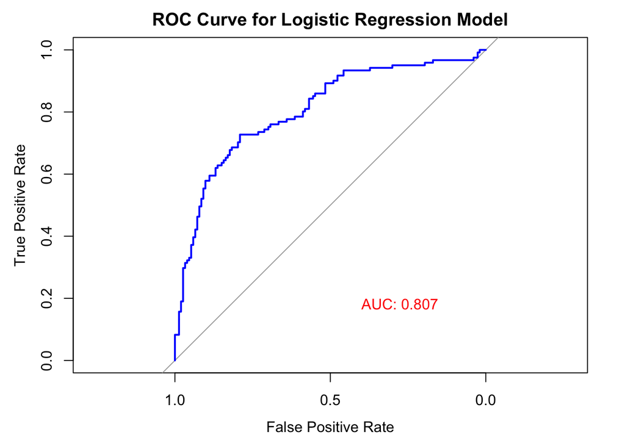

```r
# Predict on the test set using our logistic regression model
predictions_prob <- predict(logreg_model, newdata = testData, type = "response")

# Create ROC curve using the pROC package
roc_curve <- roc(testData$Flipped, predictions_prob)
# Plot ROC curve with customizations
plot(roc_curve, main = "ROC Curve for Logistic Regression Model",
     col = "blue", # Color of the ROC curve
     lwd = 2, # Line width
     xlab = "False Positive Rate", # X-axis label
     ylab = "True Positive Rate", # Y-axis label
     print.auc = TRUE, # Print the AUC on the plot
     print.auc.x = 0.4, # X location of AUC value on the plot
     print.auc.y = 0.2, # Y location of AUC value on the plot
     print.auc.col = "red" # Color of the AUC value text
)
```

#Random Forest

```r
formula <- as.formula("Flipped ~ Age + OU_LOS_hrs + Gender + DRG01 + BloodPressureUpper + BloodPressureLower + BloodPressureDiff + Pulse + PulseOximetry + Respirations + Temperature + PrimaryInsuranceCategory")

# Random Forest model
rf_model <- randomForest(formula, data = trainData, ntree = 500, importance = TRUE)

# Print the model summary
print(rf_model)
```

```
##
## Call:
##  randomForest(formula = formula, data = trainData, ntree = 500,      importance = TRUE)
##                Type of random forest: classification
##                      Number of trees: 500
## No. of variables tried at each split: 3
##
##         OOB estimate of  error rate: 25.58%
## Confusion matrix:
##     0   1 class.error
## 0 325 114   0.2596811
## 1  97 289   0.2512953
```

```r
# Predictions on the test set
predictions <- predict(rf_model, newdata = testData, type = "response")


# Convert predictions to numeric binary format if they are not already
predictions_binary <- as.numeric(predictions) - 1  # Adjust based on our factor levels if necessary

# Create a confusion matrix to evaluate model performance
confusion_matrix <- table(Actual = testData$Flipped, Predicted = predictions_binary)
print(confusion_matrix)
```

```
##       Predicted
## Actual   0   1
##      0 126  27
##      1  30  91
```

```r
# For extended evaluation metrics, load the caret package
library(caret)

# Use the confusionMatrix function from the caret package
conf_matrix <- confusionMatrix(as.factor(predictions_binary), as.factor(testData$Flipped))

# Print the confusion matrix along with additional metrics
print(conf_matrix)
```

```
## Confusion Matrix and Statistics
##
##           Reference
## Prediction   0   1
##          0 126  30
##          1  27  91
##
##                Accuracy : 0.792
##                  95% CI : (0.739, 0.8385)
##     No Information Rate : 0.5584
##     P-Value [Acc > NIR] : 4.418e-16
##
##                   Kappa : 0.5771
##
##  Mcnemar's Test P-Value : 0.7911
##
##             Sensitivity : 0.8235
##             Specificity : 0.7521
##          Pos Pred Value : 0.8077
##          Neg Pred Value : 0.7712
##              Prevalence : 0.5584
##          Detection Rate : 0.4599
##    Detection Prevalence : 0.5693
##       Balanced Accuracy : 0.7878
##
##        'Positive' Class : 0
##
```

#Variable Importance

```r
# Check variable importance
importance <- importance(rf_model)

# Print the variable importance
print(importance)
```

```
##                                   0          1 MeanDecreaseAccuracy
## Age                       2.5657441 -4.8753249           -1.6186948
## OU_LOS_hrs               57.9431222 58.1572244           73.5655285
## Gender                    3.0484378  2.3190573            3.7801625
## DRG01                    14.1417360  8.3728517           15.6534548
## BloodPressureUpper       -0.9899823  1.0288250           -0.1105269
## BloodPressureLower        0.2144995  3.0616096            2.3914192
## BloodPressureDiff        -0.8972153 -1.2821305           -1.5612230
## Pulse                    -1.6316698 -1.2683962           -1.9700659
## PulseOximetry             1.1459397 -0.7001322            0.3097727
## Respirations             -1.6929927  1.6216371           -0.1768790
## Temperature               1.8741442  2.6181048            2.9577654
## PrimaryInsuranceCategory  6.3617202  3.0804698            6.4697587
##                          MeanDecreaseGini
## Age                             24.617149
## OU_LOS_hrs                     135.940358
## Gender                           4.677211
## DRG01                           45.559823
## BloodPressureUpper              28.836783
## BloodPressureLower              28.282494
## BloodPressureDiff               32.373734
## Pulse                           26.742120
## PulseOximetry                   18.482882
## Respirations                    19.704723
## Temperature                     26.292232
## PrimaryInsuranceCategory        18.776258
```

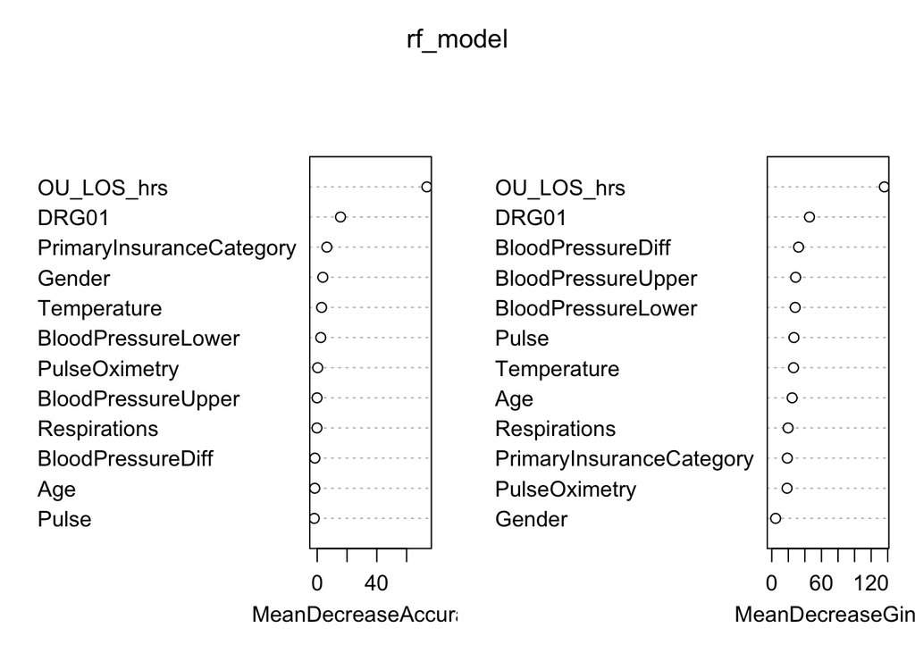

```r
# Plotting variable importance
varImpPlot(rf_model)
```

#Analysis

```r
# Simplified formula based on significance and potential relevance
simplified_formula <- as.formula("Flipped ~ OU_LOS_hrs + Gender + PrimaryInsuranceCategory")

# Fit the logistic regression model with the simplified formula
simplified_logreg_model <- glm(simplified_formula, data = trainData, family = "binomial")

# Print the summary of the simplified model
summary(simplified_logreg_model)
```

```
##
## Call:
## glm(formula = simplified_formula, family = "binomial", data = trainData)
##
## Coefficients:
##                                         Estimate Std. Error z value Pr(>|z|)
## (Intercept)                            -1.679213   0.287193  -5.847 5.01e-09
## OU_LOS_hrs                              0.028666   0.002494  11.492  < 2e-16
## GenderMale                              0.118581   0.165734   0.715   0.4743
## PrimaryInsuranceCategoryMEDICAID STATE -0.281557   0.391392  -0.719   0.4719
## PrimaryInsuranceCategoryMEDICARE        0.340413   0.293411   1.160   0.2460
## PrimaryInsuranceCategoryMEDICARE OTHER -0.610659   0.292904  -2.085   0.0371
## PrimaryInsuranceCategoryPrivate        -0.277943   0.332675  -0.835   0.4034
##
## (Intercept)                            ***
## OU_LOS_hrs                             ***
## GenderMale
## PrimaryInsuranceCategoryMEDICAID STATE
## PrimaryInsuranceCategoryMEDICARE
## PrimaryInsuranceCategoryMEDICARE OTHER *
## PrimaryInsuranceCategoryPrivate
## ---
## Signif. codes:  0 '***' 0.001 '**' 0.01 '*' 0.05 '.' 0.1 ' ' 1
##
## (Dispersion parameter for binomial family taken to be 1)
##
##     Null deviance: 1140.29  on 824  degrees of freedom
## Residual deviance:  898.37  on 818  degrees of freedom
## AIC: 912.37
##
## Number of Fisher Scoring iterations: 5
```

```r
# Predict on the test set with the simplified model
predictions_prob_simplified <- predict(simplified_logreg_model, newdata = testData, type = "response")

# Convert predicted probabilities to binary predictions
predictions_simplified <- ifelse(predictions_prob_simplified > 0.5, 1, 0)

# Create a confusion matrix to evaluate model performance
confusion_matrix_simplified <- table(Actual = testData$Flipped, Predicted = predictions_simplified)
print(confusion_matrix_simplified)
```

```
##       Predicted
## Actual   0   1
##      0 134  19
##      1  47  74
```

```r
# Use the confusionMatrix function from the caret package for the simplified model predictions
conf_matrix_simplified <- confusionMatrix(as.factor(predictions_simplified), as.factor(testData$Flipped))

# Print the confusion matrix along with additional metrics for the simplified model
print(conf_matrix_simplified)
```

```
## Confusion Matrix and Statistics
##
##           Reference
## Prediction   0   1
##          0 134  47
##          1  19  74
##
##                Accuracy : 0.7591
##                  95% CI : (0.704, 0.8085)
##     No Information Rate : 0.5584
##     P-Value [Acc > NIR] : 3.987e-12
##
##                   Kappa : 0.4995
##
##  Mcnemar's Test P-Value : 0.000889
##
##             Sensitivity : 0.8758
##             Specificity : 0.6116
##          Pos Pred Value : 0.7403
##          Neg Pred Value : 0.7957
##              Prevalence : 0.5584
##          Detection Rate : 0.4891
##    Detection Prevalence : 0.6606
##       Balanced Accuracy : 0.7437
##
##        'Positive' Class : 0
##
```

#Model Coefficients: (Intercept): The model’s intercept, -1.679213, represents the log odds of the outcome being 1 (Flipped) when all predictor variables are at their reference levels (in this case, when OU_LOS_hrs is 0, Gender is not male, and the Primary Insurance Category is the omitted reference category, likely “MEDICAID OTHER” or similar). OU_LOS_hrs: The coefficient of 0.028666 suggests that for each additional hour of stay, the log odds of flipping increase, holding other variables constant. This variable is highly significant (< 2e-16), indicating a strong and statistically significant relationship with the outcome. GenderMale: The coefficient of 0.118581 for male gender, compared to the reference category (likely female), is not statistically significant (p = 0.4743), suggesting that gender may not have a strong influence on the likelihood of flipping in this model. PrimaryInsuranceCategory: Among the insurance categories, only “MEDICARE OTHER” shows a statistically significant effect (p = 0.0371) with a coefficient of -0.610659, indicating that having this insurance category decreases the log odds of flipping compared to the reference insurance category. Other insurance categories do not show statistically significant effects. Model Fit: Null Deviance vs. Residual Deviance: The decrease from the null deviance (1140.29) to the residual deviance (898.37) indicates that the model with predictors fits the data significantly better than a model with only the intercept. AIC (Akaike Information Criterion): The AIC value of 912.37 provides a measure of the model’s quality, considering both the goodness of fit and the number of predictors used. Lower AIC values are generally better, but AIC is most useful when comparing different models. Confusion Matrix: The confusion matrix shows how the model’s predictions compare to the actual outcomes in the test data. It indicates that: True Negatives (TN): 134 instances were correctly predicted as not flipped (0). False Positives (FP): 19 instances were incorrectly predicted as flipped (1). False Negatives (FN): 47 instances that did flip were incorrectly predicted as not flipped (0). True Positives (TP): 74 instances were correctly predicted as flipped (1). Interpretation in Simple Words: This logistic regression model tries to predict whether certain conditions will flip based on how long someone stays (measured in hours), their gender, and what kind of primary insurance they have. The results show that:

The longer someone stays, the more likely their condition will flip, which is a strong and clear finding from this model. Whether someone is male or not doesn’t seem to make a significant difference to the model’s predictions. Among the insurance categories, only the “MEDICARE OTHER” category significantly affects the likelihood of flipping, and it decreases this likelihood compared to the baseline insurance category. The model is reasonably good at identifying instances that won’t flip but has room for improvement, especially in correctly identifying instances that will flip, as seen in the confusion matrix.

```r
# Calculate AUC
roc_obj <- roc(response = testData$Flipped, predictor = predictions_prob)
auc_value <- auc(roc_obj)
cat("AUC: ", auc_value, "\n")
```

```
## AUC:  0.8066224
```

```r
confusion_matrix <- table(Actual = testData$Flipped, Predicted = predictions)
accuracy <- sum(diag(confusion_matrix)) / sum(confusion_matrix)
cat("Accuracy: ", accuracy, "\n")
```

```
## Accuracy:  0.7919708
```

#Models and comparison of accuracies

```r
# Function to calculate accuracy and generate confusion matrix
calculate_metrics <- function(model, testData) {
  # Determine the model type
  model_type <- class(model)[1]

  # For logistic regression and similar models that output probabilities
  if (model_type %in% c("glm", "lm")) {
    predictions_prob <- predict(model, newdata = testData, type = "response")
    predictions <- ifelse(predictions_prob > 0.5, "1", "0")
  } else { # For models like randomForest and decision trees that directly give class predictions
    predictions <- as.character(predict(model, newdata = testData, type = "class"))
  }

  confusion_matrix <- table(Actual = testData$Flipped, Predicted = predictions)
  accuracy <- sum(diag(confusion_matrix)) / sum(confusion_matrix)

  return(list("Accuracy" = accuracy, "Confusion Matrix" = confusion_matrix))
}


metrics_logreg <- calculate_metrics(logistic_model, testData)
metrics_rf <- calculate_metrics(rf_model, testData)
metrics_simplified_logreg <- calculate_metrics(simplified_logreg_model, testData)
metrics_dt <- calculate_metrics(dt, testData)

# Updating the models and their corresponding metrics
models <- c("Logistic Regression", "Random Forest", "Simplified Logistic Regression", "Decision Tree")
accuracies <- c(metrics_logreg$Accuracy, metrics_rf$Accuracy, metrics_simplified_logreg$Accuracy, metrics_dt$Accuracy)
conf_matrices <- list(metrics_logreg$`Confusion Matrix`, metrics_rf$`Confusion Matrix`, metrics_simplified_logreg$`Confusion Matrix`, metrics_dt$`Confusion Matrix`)

# Print Accuracies
cat("## Model Accuracies\n")
```

```
## ## Model Accuracies
```

```r
for (i in 1:length(models)) {
  cat("- **", models[i], "**: ", round(accuracies[i] * 100, 2), "%\n", sep="")
}
```

```
## - **Logistic Regression**: 77.37%
## - **Random Forest**: 79.2%
## - **Simplified Logistic Regression**: 75.91%
## - **Decision Tree**: 76.64%
```

```r
# Print Confusion Matrices
cat("\n## Confusion Matrices\n")
```

```
##
## ## Confusion Matrices
```

```r
for (i in 1:length(models)) {
  cat("### ", models[i], "\n")
  print(conf_matrices[[i]])
  cat("\n")
}
```

```
## ###  Logistic Regression
##       Predicted
## Actual   0   1
##      0 133  20
##      1  42  79
##
## ###  Random Forest
##       Predicted
## Actual   0   1
##      0 126  27
##      1  30  91
##
## ###  Simplified Logistic Regression
##       Predicted
## Actual   0   1
##      0 134  19
##      1  47  74
##
## ###  Decision Tree
##       Predicted
## Actual   0   1
##      0 125  28
##      1  36  85
```

#Model Averages prediction

```r
calculate_avg_los <- function(model, testData) {
  # Determine model type and predict
  if (class(model)[1] == "glm" || class(model)[1] == "lm") {
    # For logistic regression, predict probabilities and convert to binary
    predictions_prob <- predict(model, newdata = testData, type = "response")
    predictions <- ifelse(predictions_prob > 0.5, 1, 0)
  } else {
    # For models like randomForest that directly give class predictions
    predictions <- as.numeric(predict(model, newdata = testData, type = "class"))
  }

  # Calculate average OU_LOS_hrs for Flipped = 1
  avg_los_flipped_1 <- mean(testData$OU_LOS_hrs[predictions == 1], na.rm = TRUE)

  return(avg_los_flipped_1)
}

# Calculating average OU_LOS_hrs for Flipped = 1 for each model
avg_los_logreg <- calculate_avg_los(logreg_model, testData)
avg_los_rf <- calculate_avg_los(rf_model, testData)
avg_los_simplified_logreg <- calculate_avg_los(simplified_logreg_model, testData)
avg_los_dt <- calculate_avg_los(dt, testData)

# Print average OU_LOS_hrs for Flipped = 1 for each model
cat("## Average OU_LOS_hrs for Flipped = 1\n")
```

```
## ## Average OU_LOS_hrs for Flipped = 1
```

```r
cat("- **Logistic Regression**: ", avg_los_logreg, "hrs\n")
```

```
## - **Logistic Regression**:  109.3511 hrs
```

```r
cat("- **Random Forest**: ", avg_los_rf, "hrs\n")
```

```
## - **Random Forest**:  32.30323 hrs
```

```r
cat("- **Simplified Logistic Regression**: ", avg_los_simplified_logreg, "hrs\n")
```

```
## - **Simplified Logistic Regression**:  107.9355 hrs
```

```r
cat("- **Decision Tree**: ", avg_los_dt, "hrs\n")
```

```
## - **Decision Tree**:  31.41988 hrs
```